# Frequency distribution of steps per day

Load the libraries used later and then load the datafile into a dataframe called stepsData. Assumes activity.csv is in working directory.

```r
library(dplyr)
library(lubridate)
library(lattice)

stepsData<-read.csv("activity.csv")
```

### Frequency distribution of steps per day

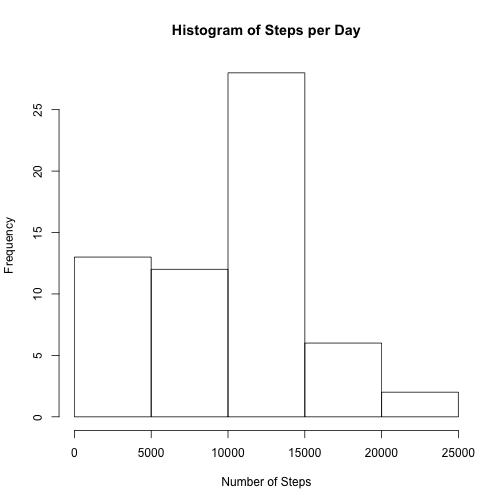

```r
stepsGrouped<-group_by(stepsData,date)
stepsPerDay<-summarise(stepsGrouped,StepsPerDay=sum(steps,na.rm=TRUE))

hist(stepsPerDay$StepsPerDay,main="Histogram of Steps per Day",xlab="Number of Steps",ylab="Frequency")
```

### Overall mean and median steps per day

Calculate mean and median steps per day

```r
meanspd<-mean(stepsPerDay$StepsPerDay, na.rm=TRUE)
medianspd<-median(stepsPerDay$StepsPerDay,na.rm=TRUE)
meanspd
```

```
## [1] 9354.23
```

```r
medianspd
```

```
## [1] 10395
```

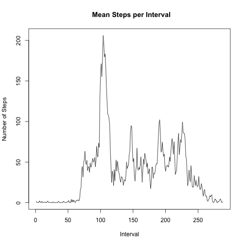

```r
stepsGroupedByInterval<-group_by(stepsData,interval)
stepsPerInterval=summarise(stepsGroupedByInterval, meanStepsInt=mean(steps,na.rm=TRUE))
plot(stepsPerInterval$meanStepsInt,type="l",main="  Mean Steps per Interval",xlab="Interval",ylab="Number of Steps")
```

### Which interval has the highest mean number of steps?

The maximum value for mean steps

```r
maxInterval <- stepsPerInterval[which(stepsPerInterval$meanStepsInt==max(stepsPerInterval$meanStepsInt)),]
maxInterval
```

```
## Source: local data frame [1 x 2]
##
##   interval meanStepsInt
## 1      835     206.1698
```

### How many missing values are there?

The number of missing values for steps

```r
numMissing<- sum(is.na(stepsData$steps))
numMissing
```

```
## [1] 2304
```

### Imputation.

I have chosen to replace the missing values for steps with the mean number of steps for the relevant interval from all days. Replacing the missing values in this way would be expected to increase the number of steps on each day. The results confirm this and this is also reflecte din the greater mean and median steps per day.

```r
AddMeanStepsPerInterval<-inner_join(stepsGrouped,stepsPerInterval)
```

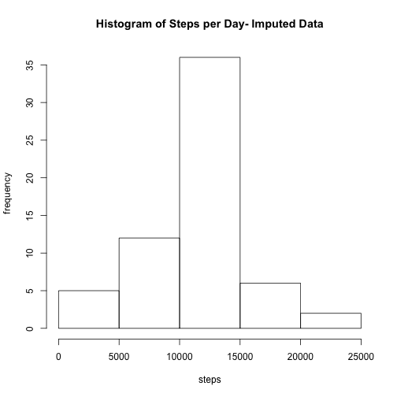

```r
AddMeanStepsPerInterval$steps[is.na(AddMeanStepsPerInterval$steps)]<-AddMeanStepsPerInterval$meanStepsInt[is.na(AddMeanStepsPerInterval$steps)]

ImpStepsGroupedByDate <- group_by(AddMeanStepsPerInterval,date)
ImpStepsPerDay<-summarise(ImpStepsGroupedByDate,ImpSteps=sum(steps))

hist(ImpStepsPerDay$ImpSteps,main="Histogram of Steps per Day- Imputed Data",xlab="steps",ylab="frequency")
```

### Mean and median steps per day - imputed data

```r
meanstpImp<-mean(ImpStepsPerDay$ImpSteps)
medianstpImp<-median(ImpStepsPerDay$ImpSteps)
meanstpImp
```

```
## [1] 10766.19
```

```r
medianstpImp
```

```
## [1] 10766.19
```

### How does the number of steps vary on weekdays and at the weekend?

Add a column to the data for weekend/weekday Then create a copy of the original data, and change the steps column of the copy to the imputed values Then Group by Interval and whether weekend or not, and summarise data to give mean nuber of steps for each interval for weekend and weekday

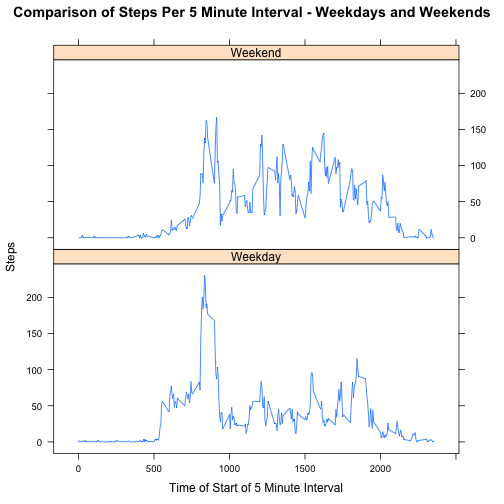

```r
stepsData<-mutate(stepsData,dayType=ifelse
          (weekdays(ymd(as.character(stepsData$date)))=="Saturday"|weekdays(ymd(as.character(stepsData$date)))=="Sunday"
           ,"Weekend","Weekday"))
stepsDataCopy<-stepsData
stepsDataCopy$steps<-AddMeanStepsPerInterval$steps
weekendGrouping<-group_by(stepsDataCopy,interval,dayType)
WeekendData<-summarise(weekendGrouping,dayTypeSteps=mean(steps))
xyplot(dayTypeSteps~interval|dayType,data=WeekendData,type="l",layout=c(1,2),main="Comparison of Steps Per 5 Minute Interval - Weekdays and Weekends", xlab="Time of Start of 5 Minute Interval",ylab="Steps")
```